# SWA_Paired_AOI

## **2023**

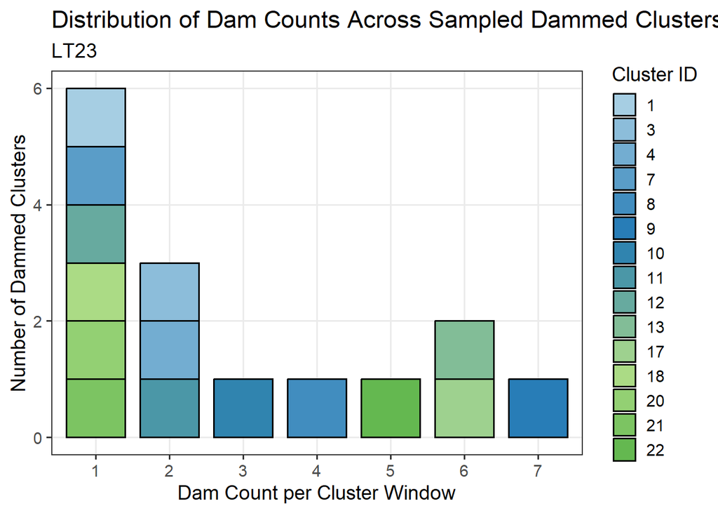

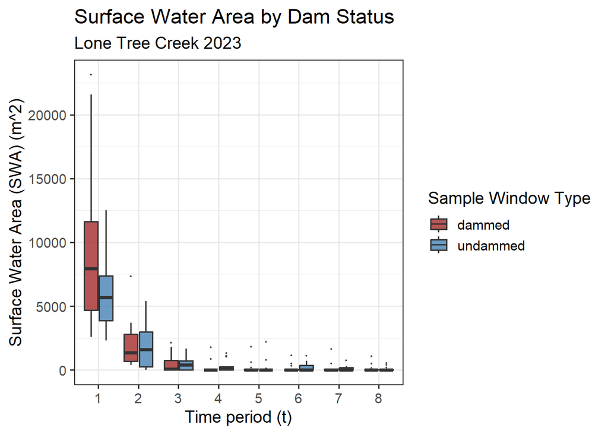

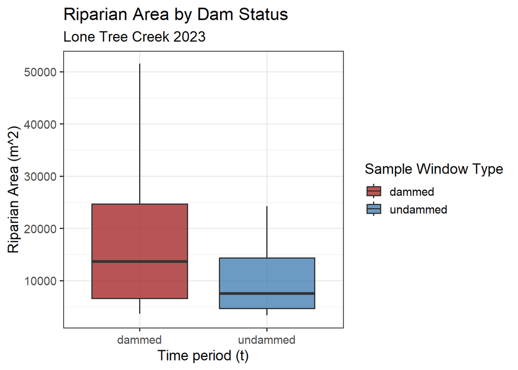

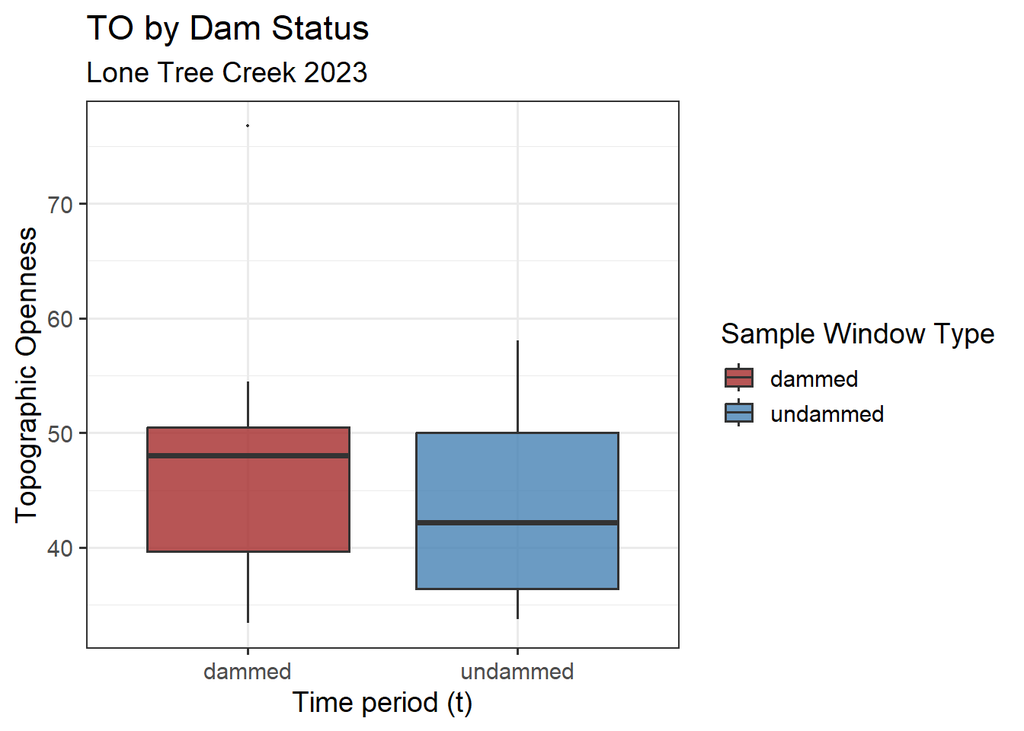

## —-

## —-

## **BRAZIL**

## **2019**

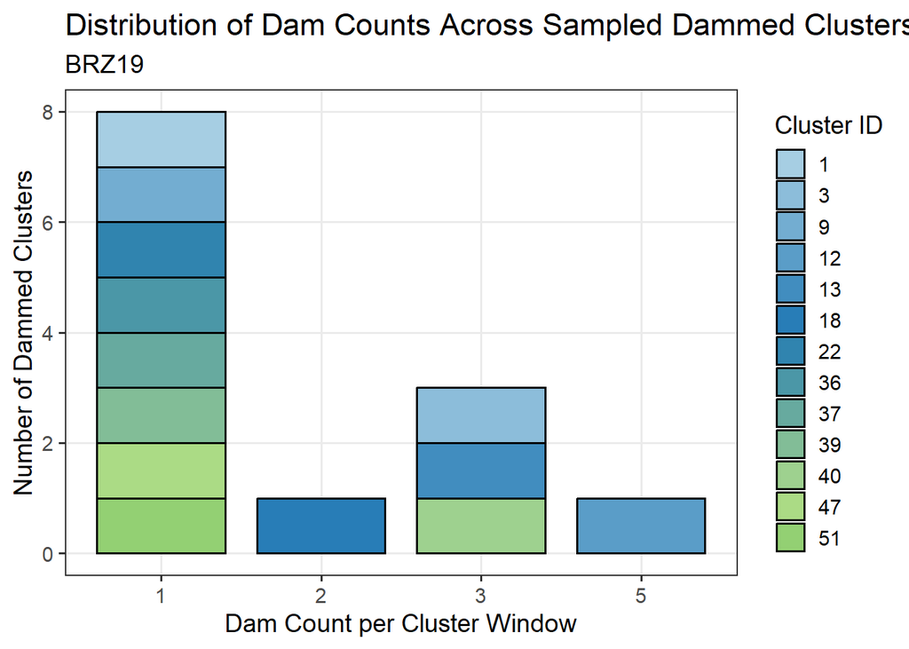

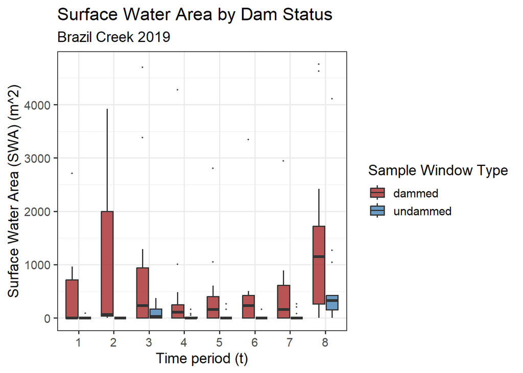

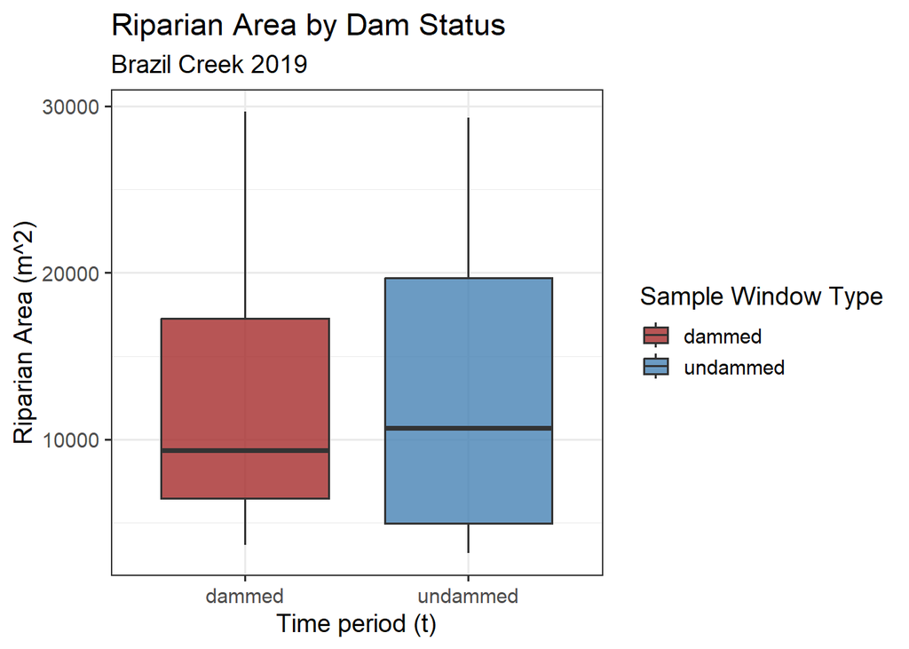

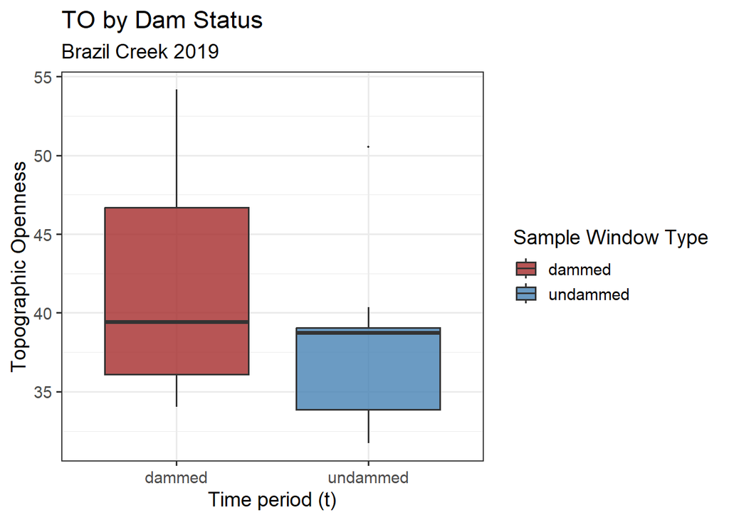

## **2021**

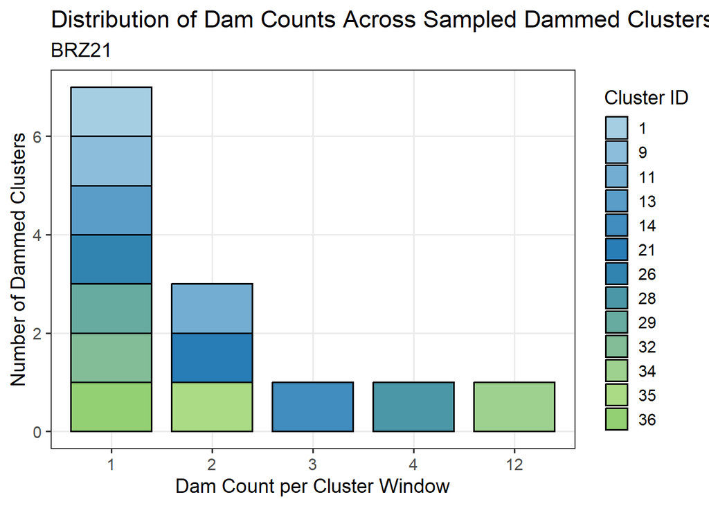

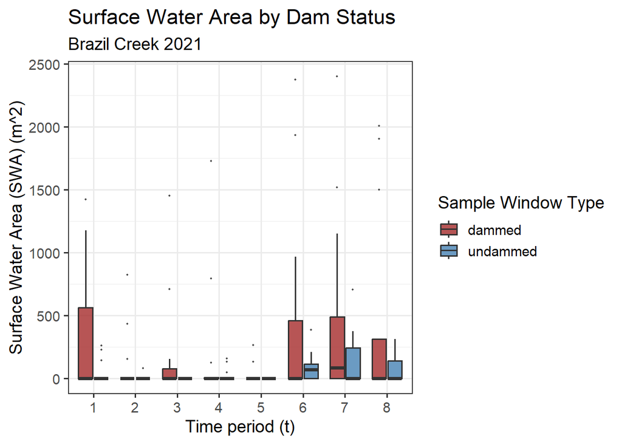

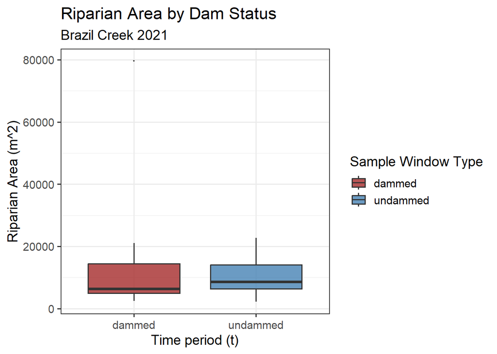

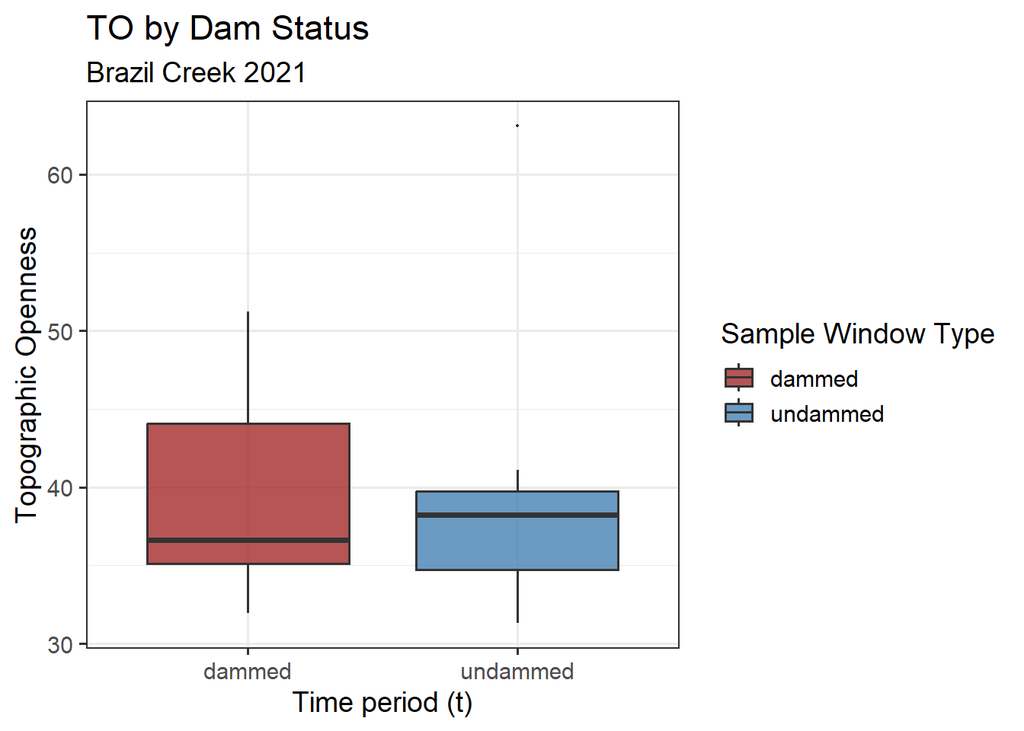

## **2023**

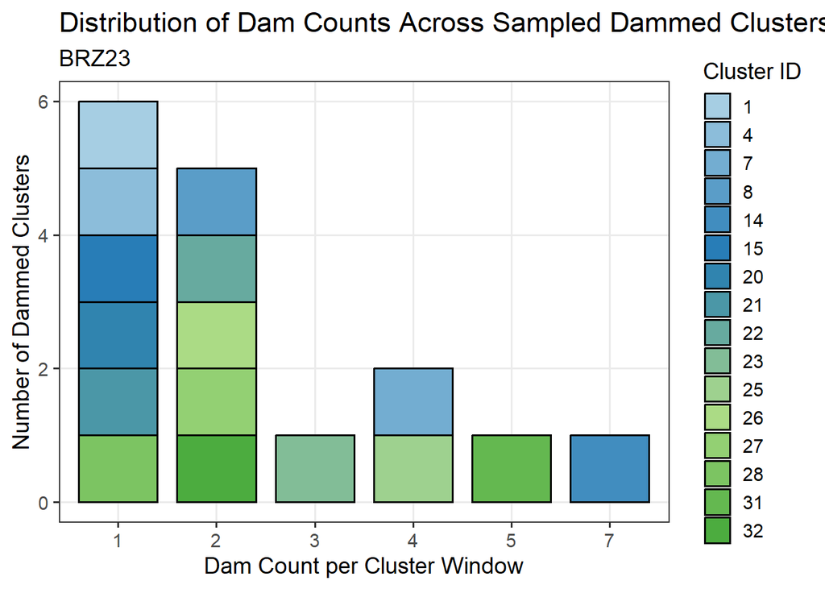

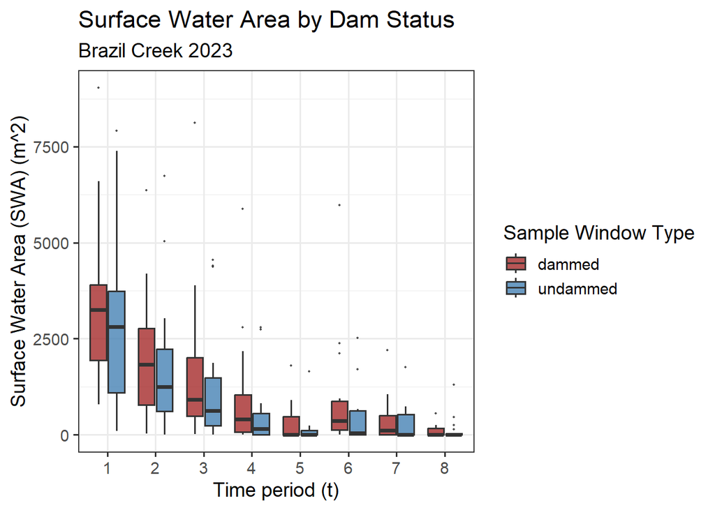

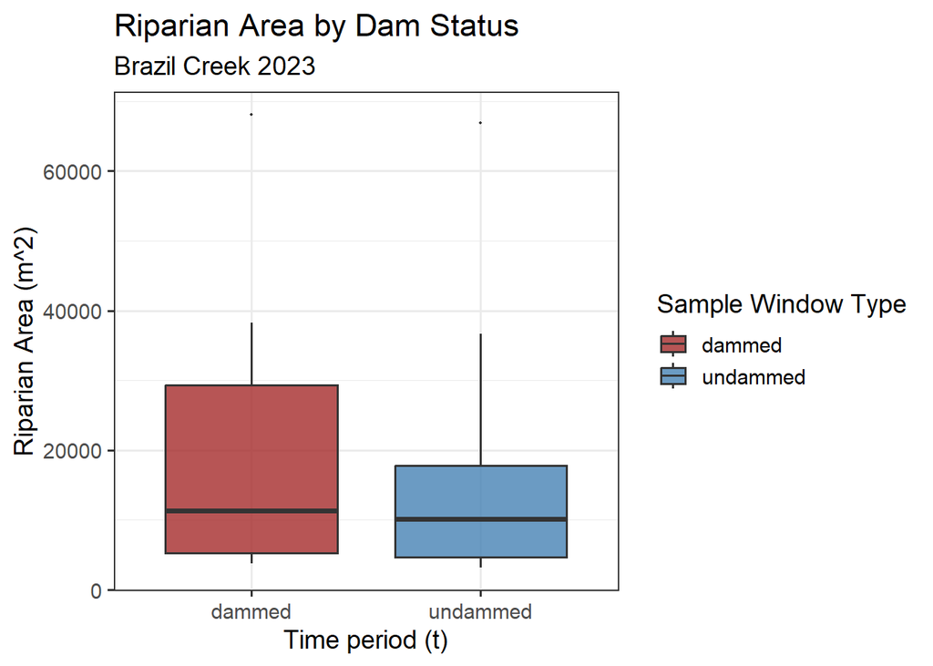

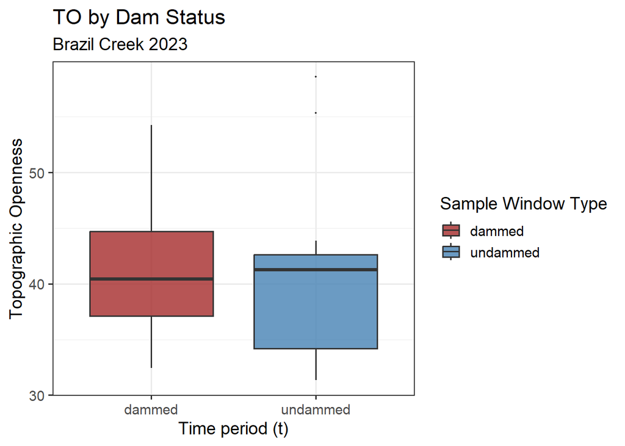

## —-

## —-

## **LARB**

## **2019**

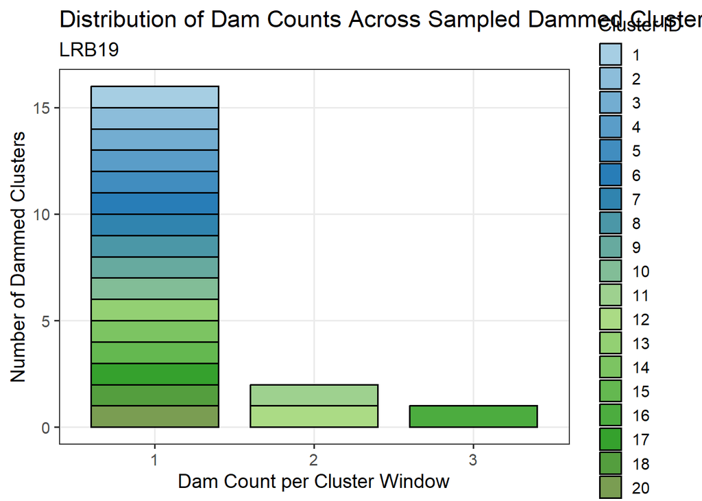

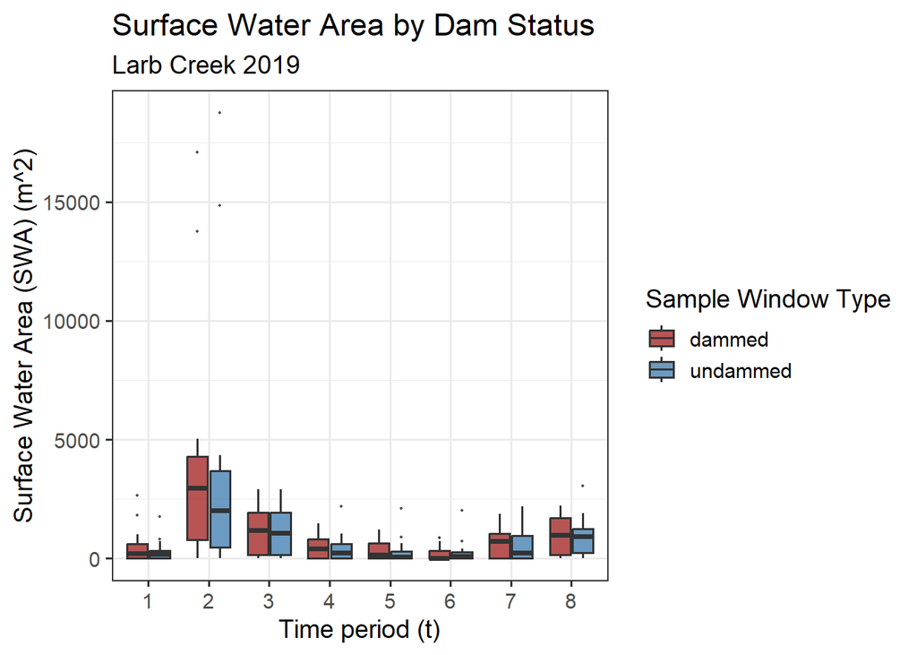

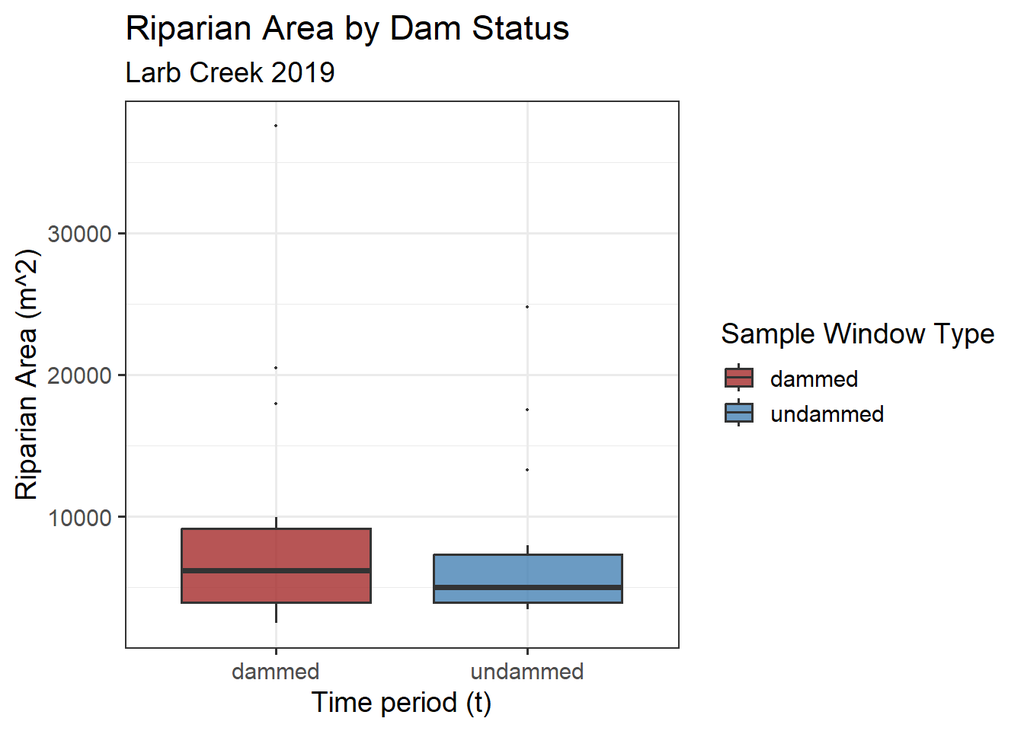

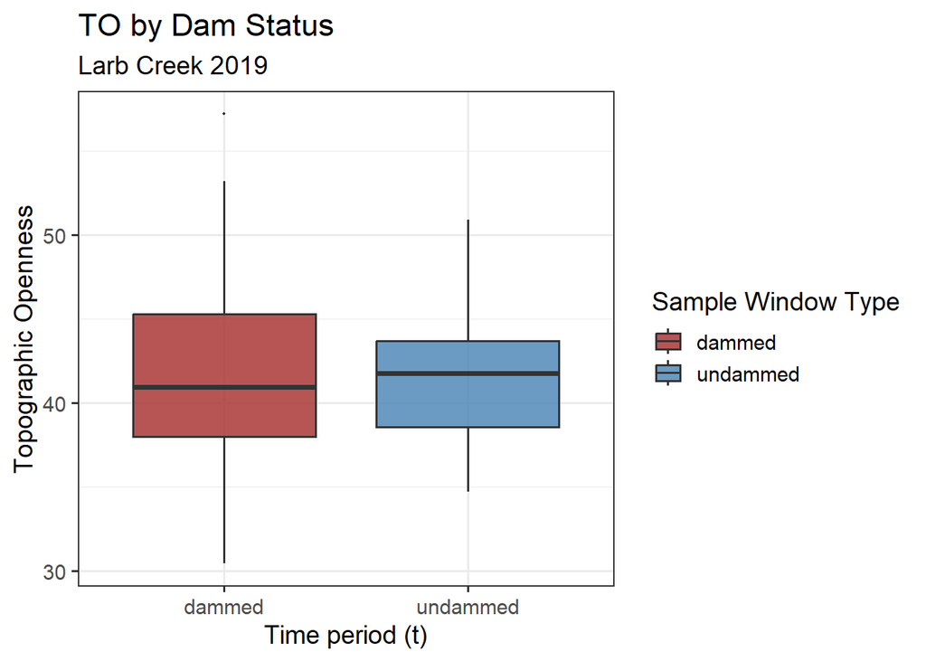

## **2021**

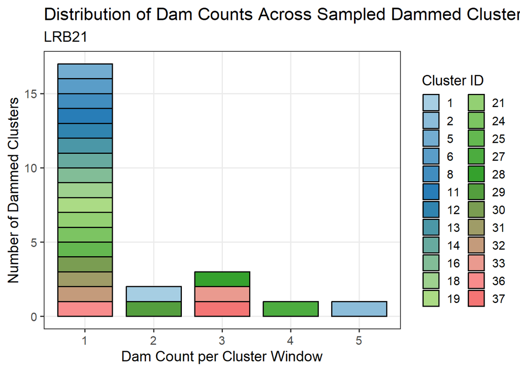

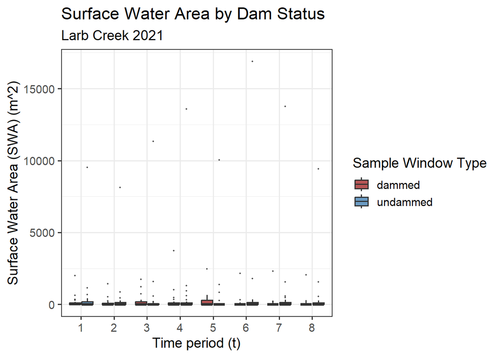

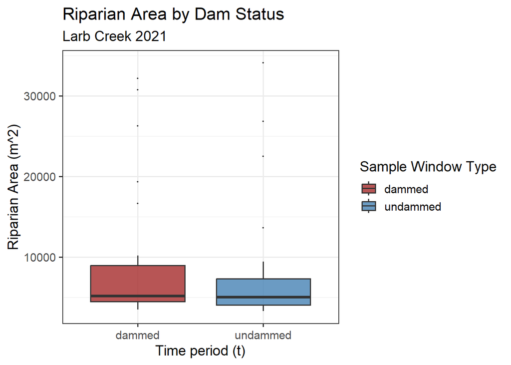

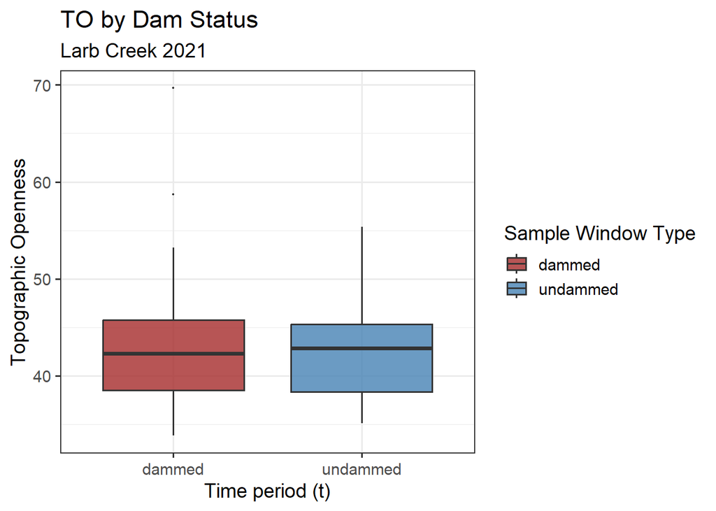

## **2023**

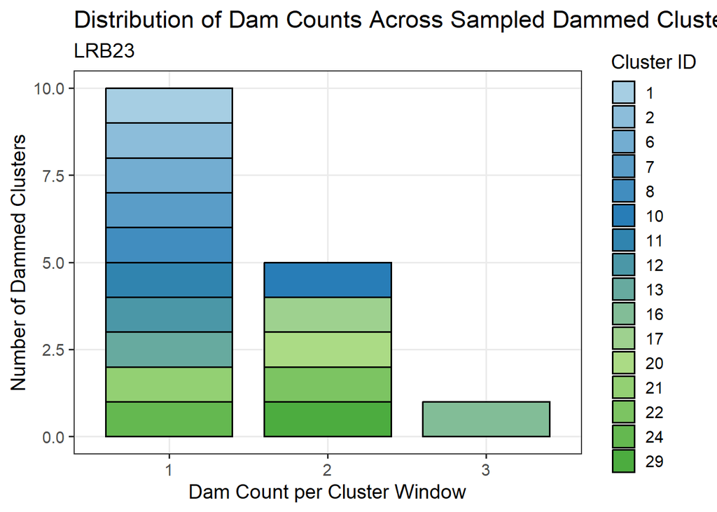

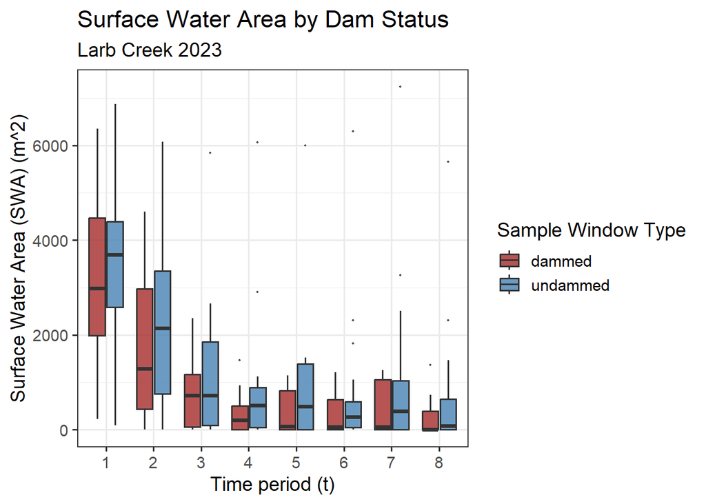

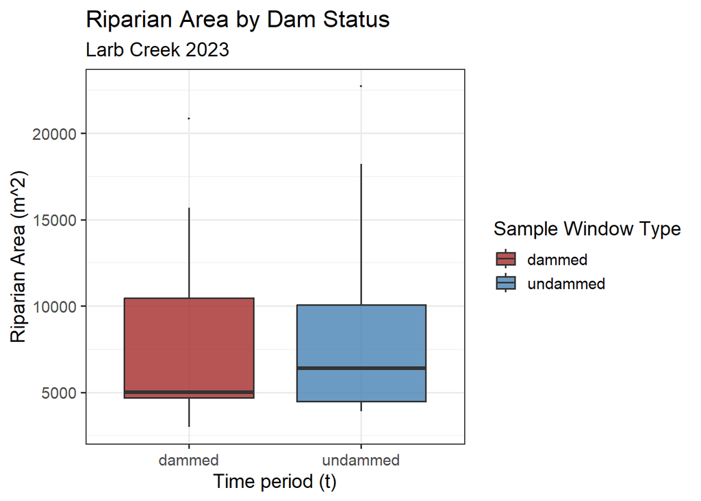

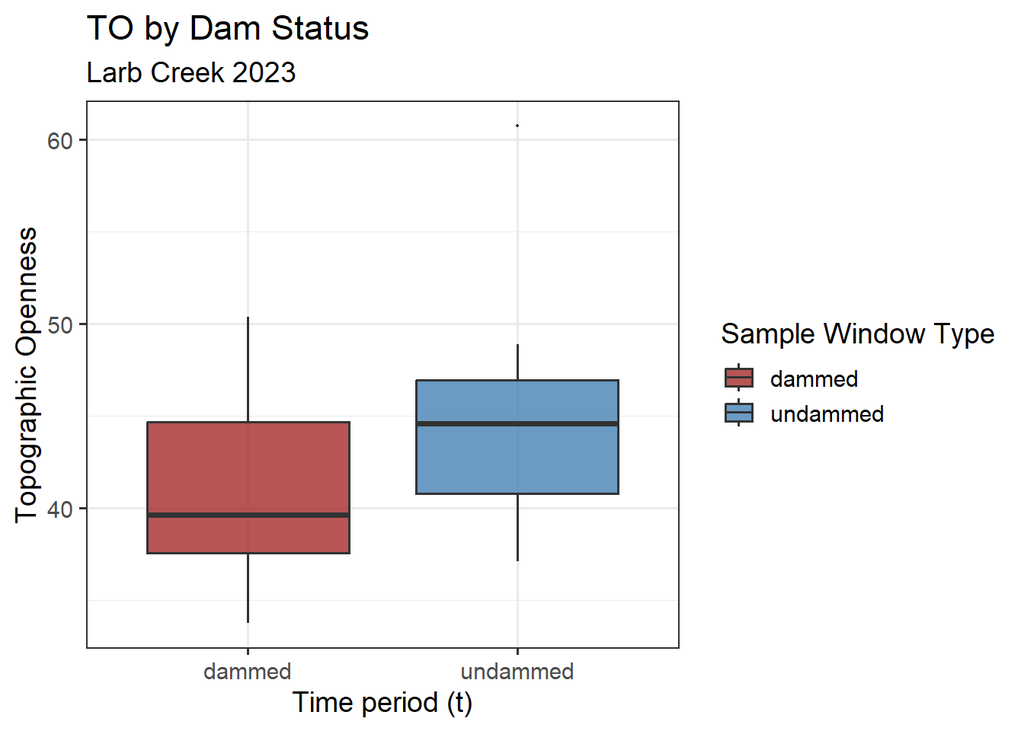

## —-

## —-

## **LOWER BEAVER**

## **2019**

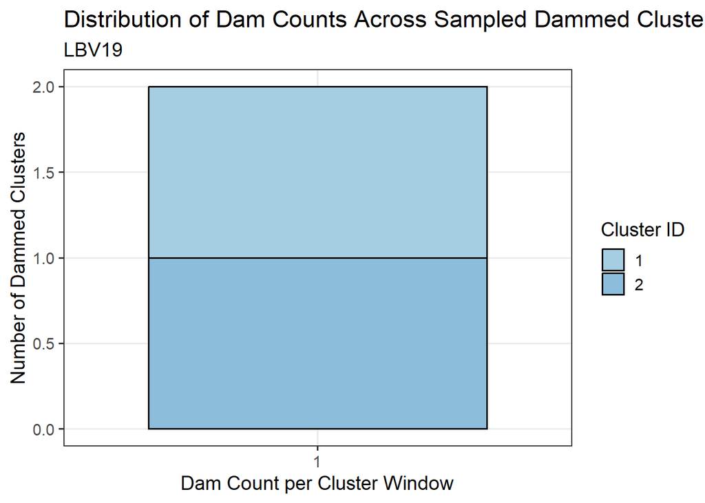

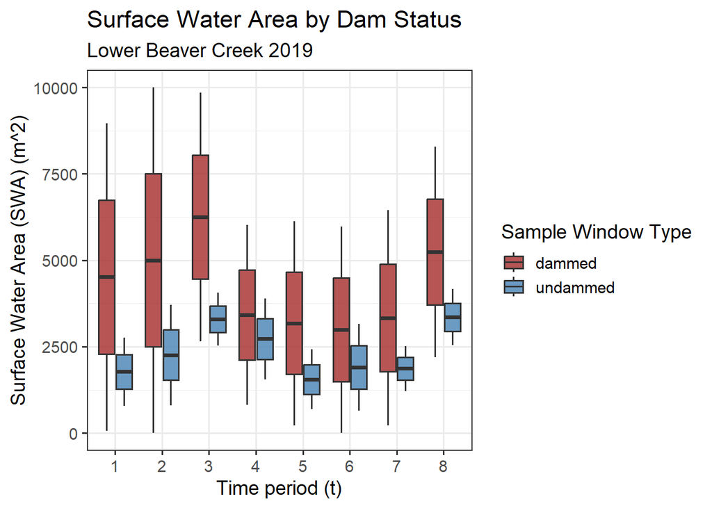

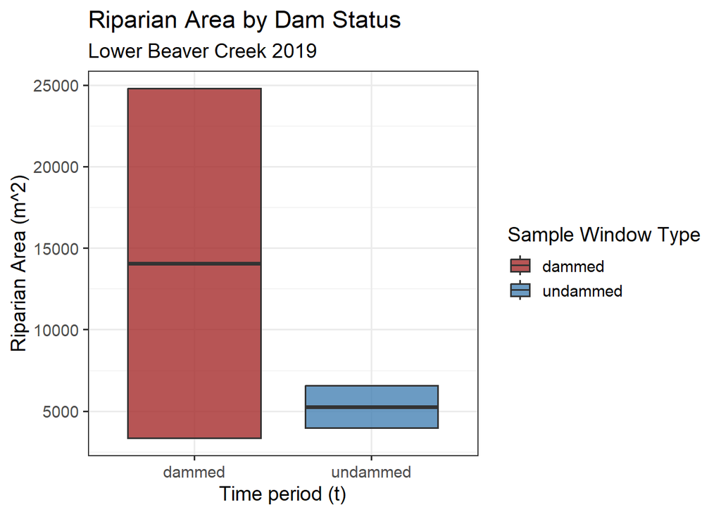

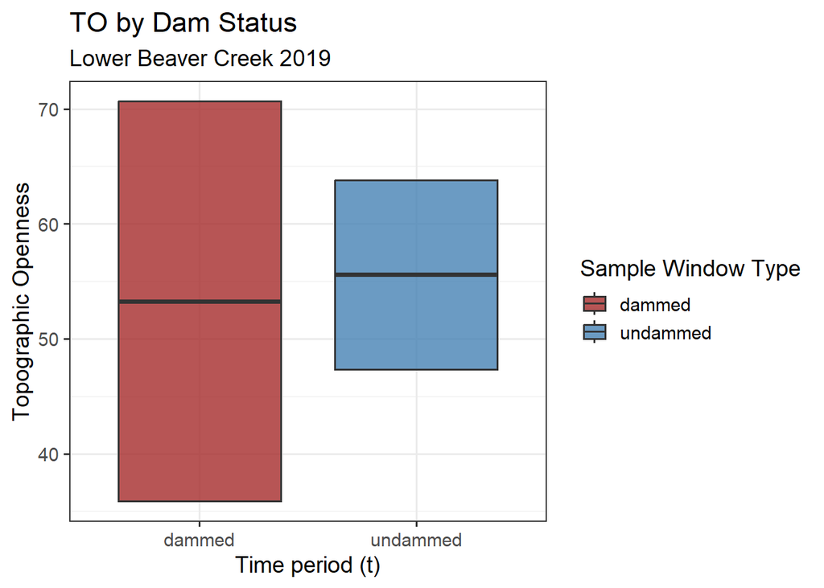

## **2021**

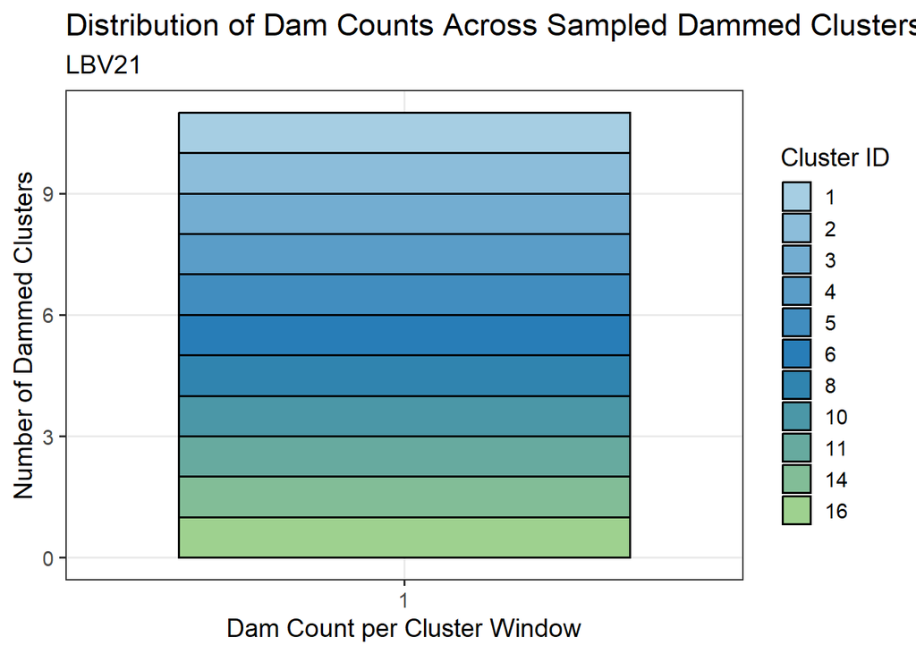

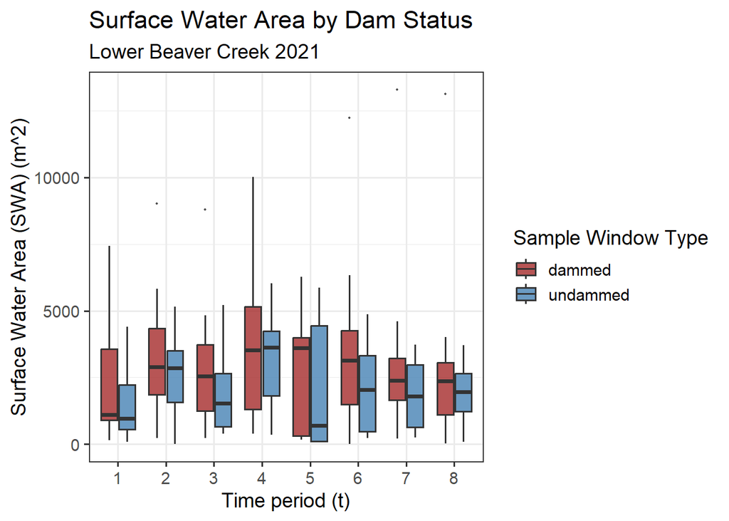

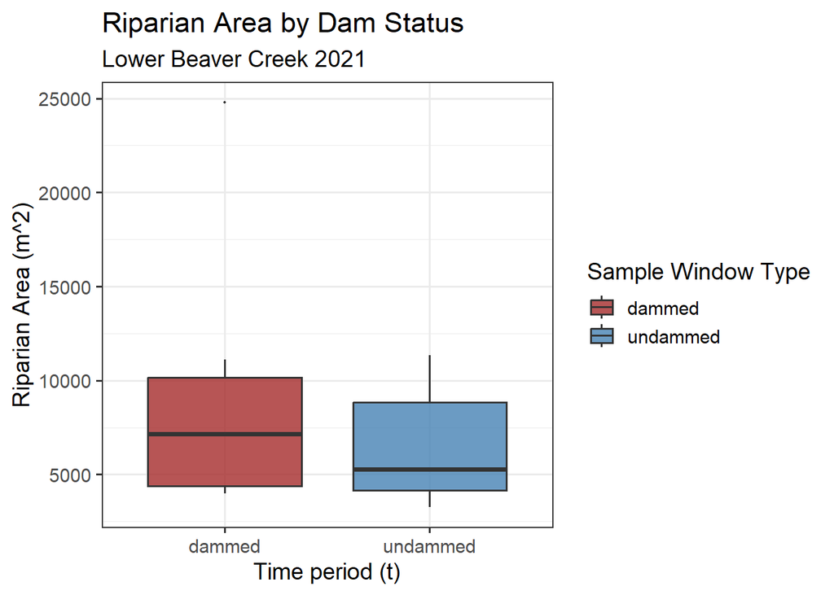

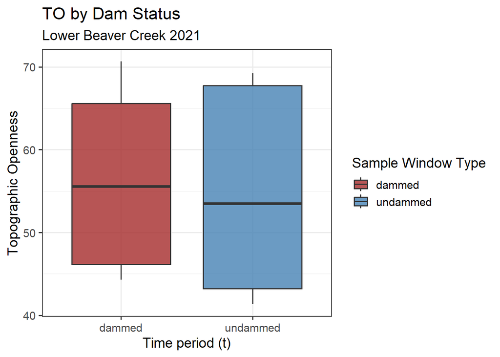

## **2023**

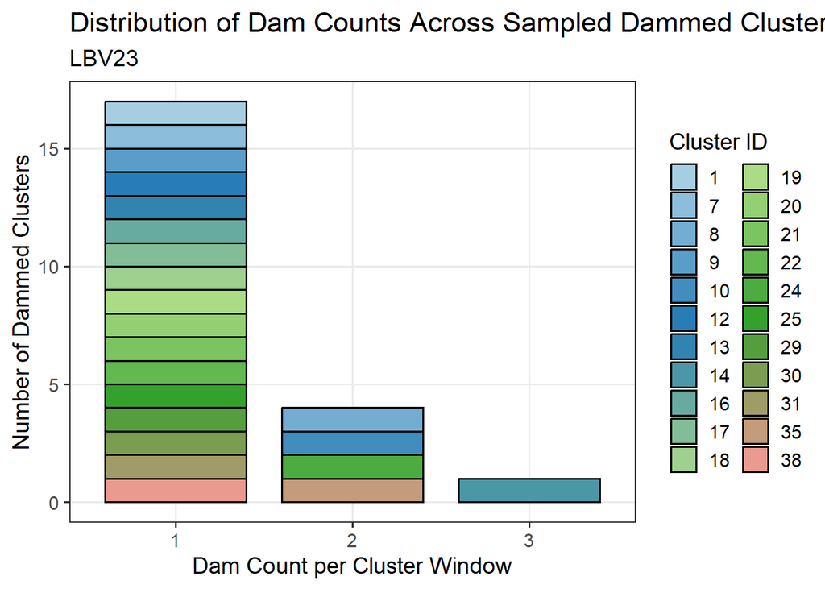

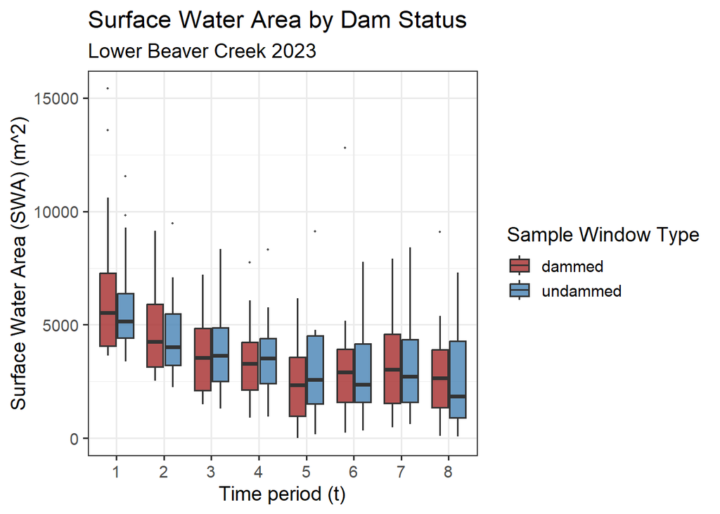

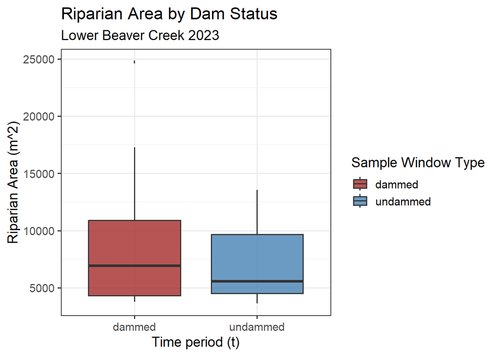

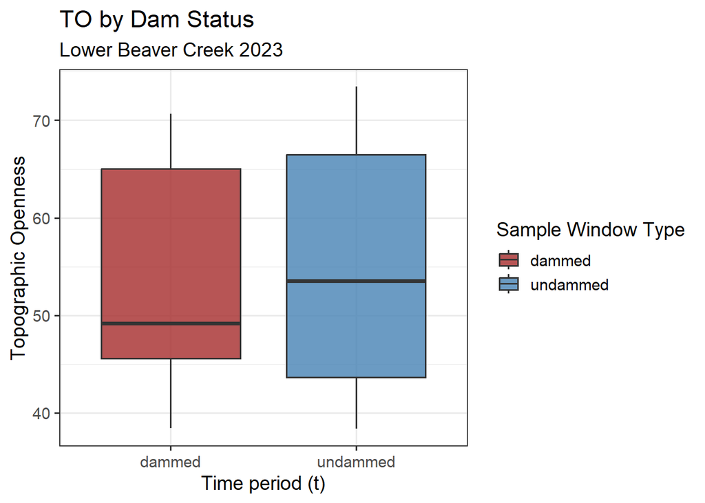

## —-

## —-

## **UPPER BEAVER**

## **2019**

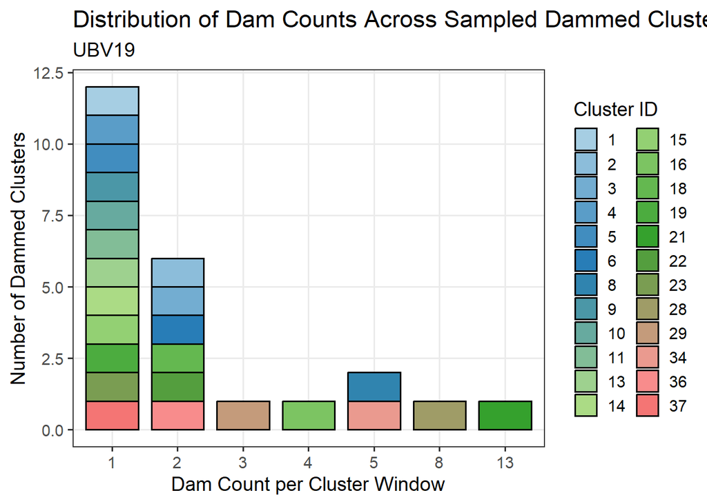

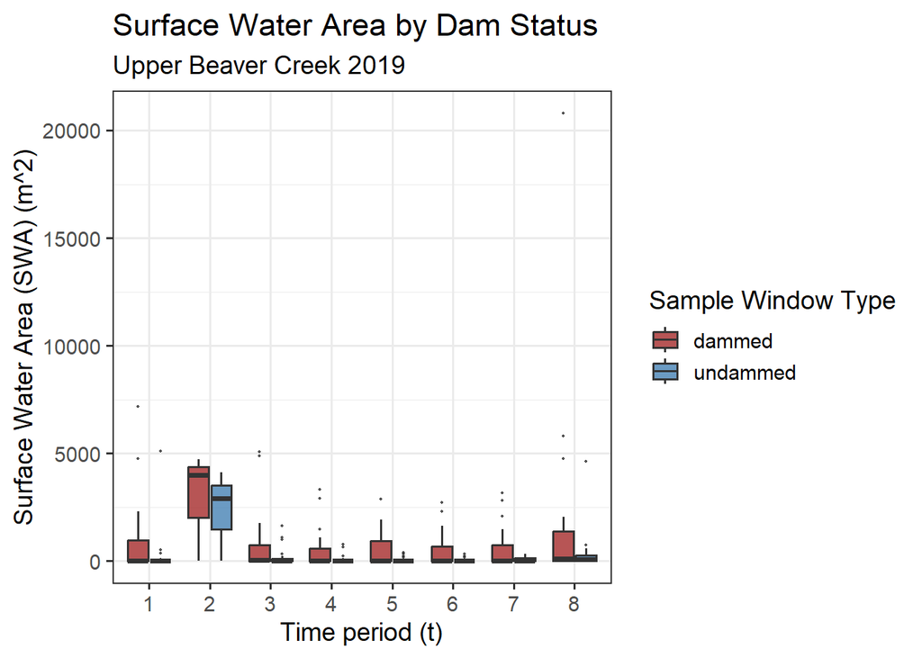

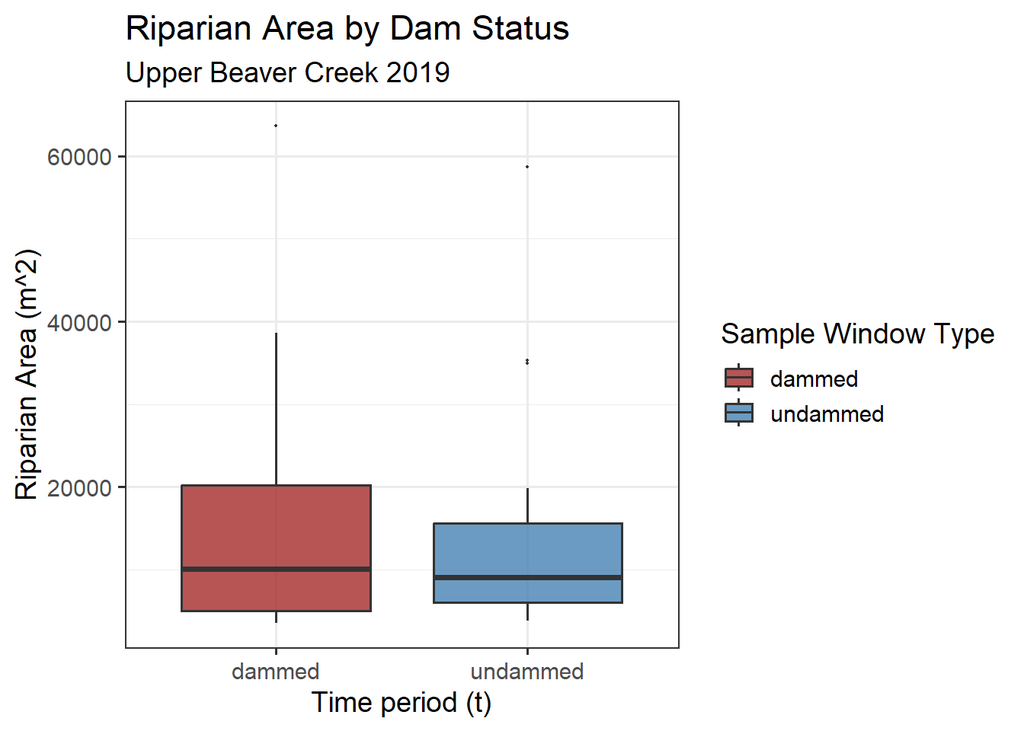

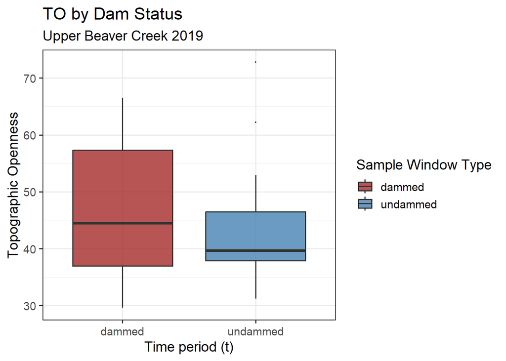

## **2021**

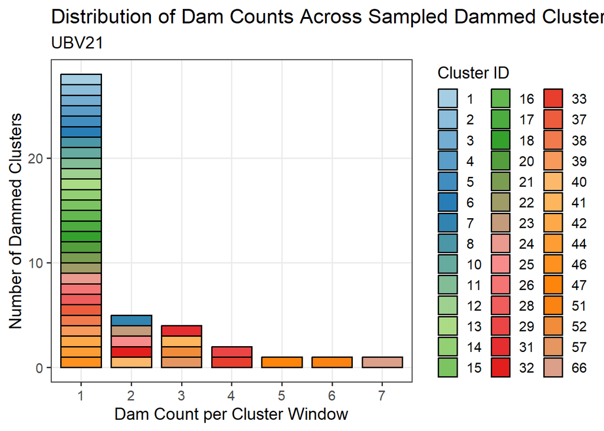

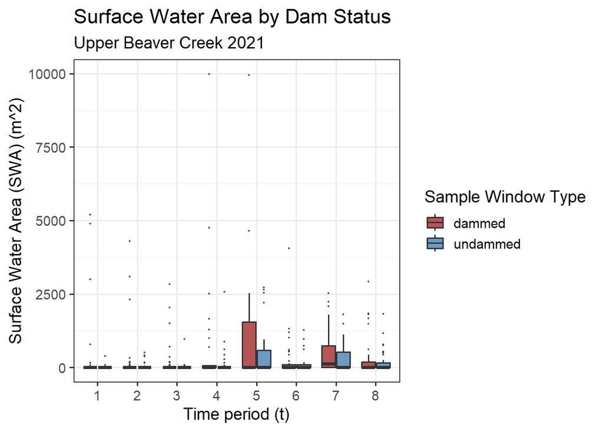

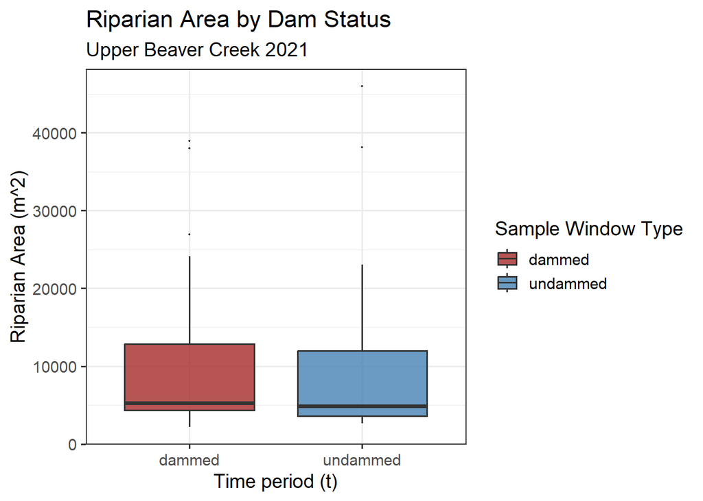

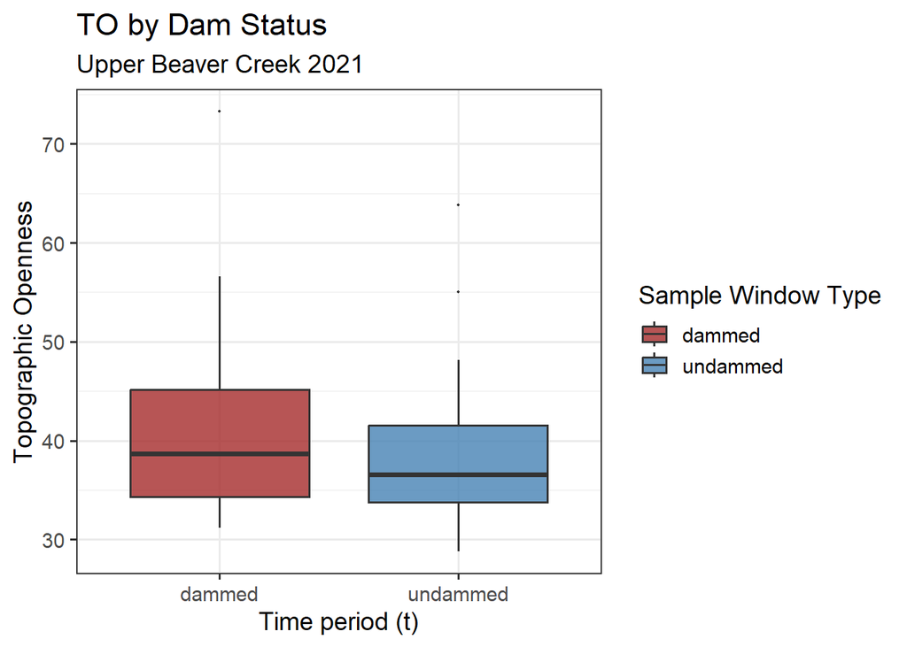

## **2023**

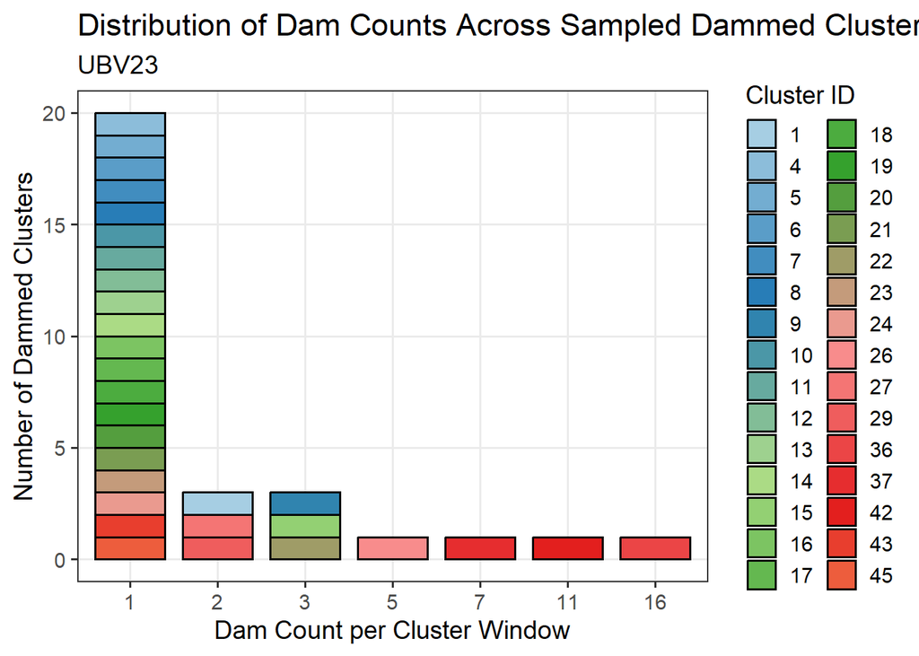

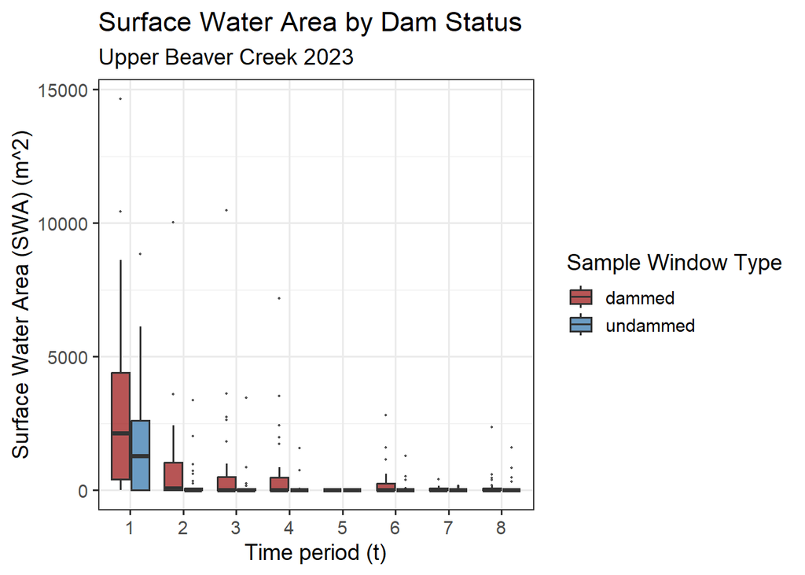

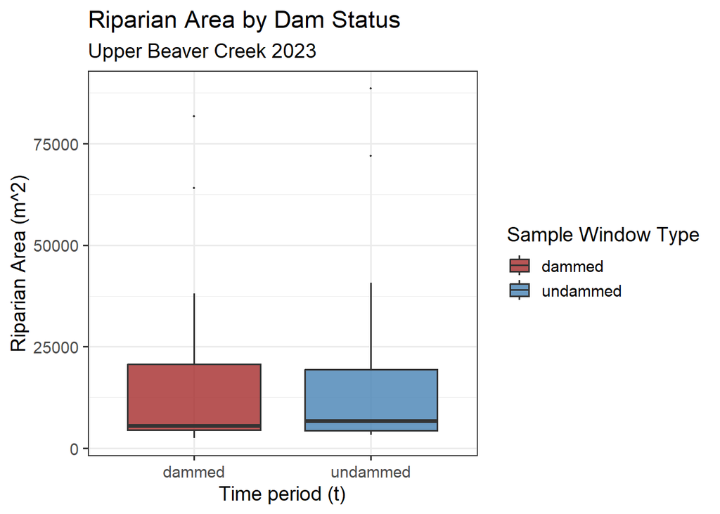

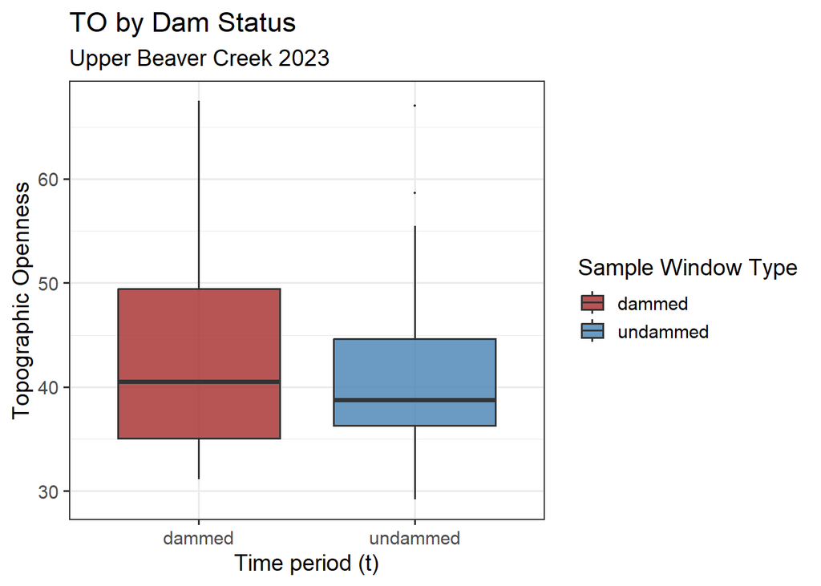

EXPLORE POTENTIAL WATERSHED LEVEL EFFECTS:

DOES DAM_DENSITY[watershed] influence RI[watershed]?

ONLY COMPARE t5:t8; t1:t4 for 2023 saw MASSIVE flooding that certainly wiped out dams; for comparability’s sake, remove t1:t4 from consideration

Compare watersheds across time:

```
6 watersheds

3 years

4 time periods (t5:t8)
  - August & September
```

For each watershed/year combo, condense the “…*SW*…_collapsed” data frame to a single, summed row, with columns: watershed; SWAt1:SWAt8; riparian_area_m – where SWA for each time period, and riparian_area_m2 are each summed across the entire watershed.

Then, bind_rows, to join each watershed/year together into a single data frame & compute RI for each.

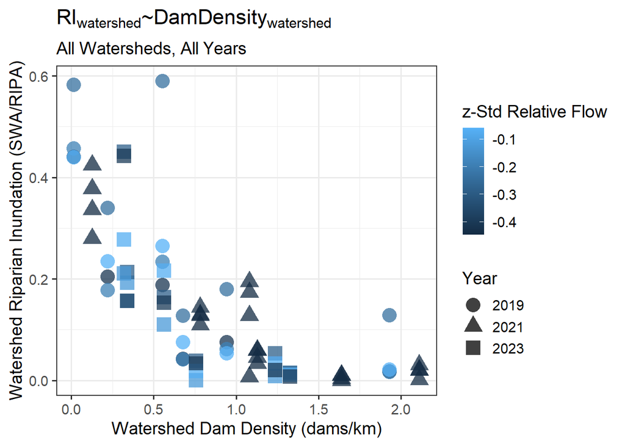

[interactive chart not shown]